# FigureYa62twoAxis

**Author(s)**: Xiaojian Liu  
**Reviewer(s)**: Ying Ge, Yijing Chen  
**Date**: 2025-12-18

## 1 Academic Citation

If you use this code in your work or research, we kindly request that you cite our publication:

Xiaofan Lu, et al. (2025). FigureYa: A Standardized Visualization Framework for Enhancing Biomedical Data Interpretation and Research Efficiency. iMetaMed. https://doi.org/10.1002/imm3.70005

## 2 需求描述 Requirement description

复现文中的线性回归，画出双坐标轴的图

Reproduce the linear regression in the text and draw a dual-axis graph.

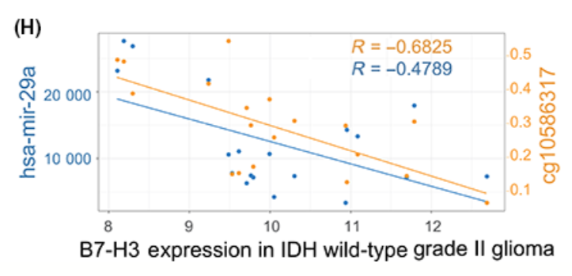

From https://onlinelibrary.wiley.com/doi/full/10.1111/cas.13744

## 3 应用场景 Application scenario

同时计算和展示3组数据的相关性，A vs. B 和 A vs. C。

例如例文中同时展示B7-H3表达跟mir-29a的相关性，以及跟甲基化的相关性。由此看出：In IDH‐wild grade II gliomas, B7‐H3 expression seemed to be downregulated by both methylation on cg10586317 and microRNA‐29a, rationalizing the paradox in grade II gliomas with wild‐type IDH.

Simultaneously calculate and display the correlation of 3 groups of data, A vs. B and A vs. C.

For example, the sample text simultaneously shows the correlation of B7-H3 expression with mir-29a, as well as with methylation. From this, it can be seen: In IDH‐wild grade II gliomas, B7‐H3 expression seemed to be downregulated by both methylation on cg10586317 and microRNA‐29a, rationalizing the paradox in grade II gliomas with wild‐type IDH.

## 4 环境设置 Environment setting

```r
source("install_dependencies.R")
```

```
## Starting R package installation...
## ===========================================
##
## Installing CRAN packages...
## Package already installed: ggplot2
## Package already installed: grid
## Package already installed: gtable
## Installing CRAN package: panel
```

```
##
## ===========================================
## Package installation completed!
## You can now run your R scripts in this directory.
```

```r
library(ggplot2) #强大的绘图系统 Powerful plotting system
library(gtable) # 表格布局工具 Table layout tool
library(grid) # 网格布局工具 Grid layout tool

Sys.setenv(LANGUAGE = "en") #显示英文报错信息 display English error messages
options(stringsAsFactors = FALSE) #禁止chr转成factor prohibit the conversion of chr to factor
```

## 5 参数设置 Parameter setting

```r
## 两个坐标轴的颜色
## the color of the two axes
s1Colour="#6B9EC2"
s2Colour="#EE861A"

## xlab
xtitle="mRNA expression"
## ylab
ylefttitle="miRNA"
yrighttitle="cg10586317"

##Aspect ration of picture，图的宽高比例
AspectRatio = 5/2
```

## 6 输入文件 Input file

包含三列：对应X轴和两个Y轴

分别对应例文中的X轴：mRNA表达量，可以是FPKM等值。

左侧Y轴：miRNA的表达量

右侧Y轴：DNA甲基化水平

It contains three columns: corresponding to the X-axis and two Y-axes

Corresponding to the X-axis in the example text respectively: mRNA expression level, which can be equivalent to FPKM.

Left Y-axis: miRNA expression level

Right Y-axis: DNA methylation level

```r
inputData <- read.table("easy_input.txt", header = T)
head(inputData)
```

```
##      X    Y1   Y2
## 1  8.5 26000 0.65
## 2  9.0 24500 0.60
## 3  9.5 23300 0.55
## 4 10.0 10500 0.56
## 5 10.5 15000 0.40
## 6 11.0 10000 0.30
```

```r
#inputData$Y2 <- inputData$Y1 * 0.00001
#所有次坐标轴必须基于主坐标轴的一一对应变换。
#默认右侧Y轴跟左侧Y轴范围是一样的，然而示例数据的Y1和Y2范围差距很大，因此需要用Y1和Y2的数值计算两个Y轴的比例
#All secondary axes must be based on a one-to-one transformation of the primary axes.
#by default, range of the right Y-axis is the same as that of the left Y-axis, however, there is a big difference between the ranges of Y1 and Y2 in the example data, so we need to calculate the ratio of the two Y-axes using the values of Y1 and Y2
(scaleFactor <- max(inputData$Y1) / max(inputData$Y2))
```

```
## [1] 40000
```

```r
#在画右侧Y轴、X和Y2的散点和拟合线时都要用这个比例来换算
#除了用乘法，你还可以用加法
#when drawing the scatter and fitting lines for the right Y-axis, X, and Y2, use this ratio for conversion
#besides multiplication, you can also use addition

#前面参数设置了图的宽高比例，保存在AspectRatio里
#用Y1和Y2的数值换算坐标轴的宽高比，在后面的画图代码coord_fixed中要用到
#the previous parameter sets the aspect ratio of the diagram, which is saved in AspectRatio
#use the values of Y1 and Y2 to convert the aspect ratio of the axes, which will be used later in the drawing code coord_fixed
(ratioValues <- ((max(inputData$X)-min(inputData$X))/(max(inputData$Y1)-min(inputData$Y1))) / AspectRatio)
```

```
## [1] 8e-05
```

## 7 计算相关系数 Calculate the correlation coefficient

```r
#写一个计算相关系数的函数，同时写成图中的格式
#write a function that calculates the correlation coefficient while writing it in the format shown in the figure
correlation <- function(data,X,Y){
  #计算相关系数
  #calculate the correlation coefficient
  R <- cor(X,Y,method = "pearson") #或"pearson", "kendall"

  #把相关系数写成图中展示的格式
  #write the correlation coefficients in the format shown in the figure
  eq <- substitute(~~italic(R)~"="~r, list(r = format(round(R, 4),nsmall= 4)))
  Req <- as.character(as.expression(eq))
  return(Req)
}

#用上面的函数分别计算mRNA跟miRNA、DNA甲基化之间的相关系数
#calculate the correlation coefficients between mRNA and miRNA and DNA methylation using the function above respectively
(R1cor <- correlation(inputData,inputData$X,inputData$Y1))
```

```
## [1] "~~italic(R) ~ \"=\" ~ \"-0.9210\""
```

```r
(R2cor <- correlation(inputData,inputData$X,inputData$Y2))
```

```
## [1] "~~italic(R) ~ \"=\" ~ \"-0.9300\""
```

## 8 开始画图 Start drawing

此处提供两种方法画图：

- 方法一，优点：简单，易于理解；缺点：右侧Y轴的label的文字方向与原文相反。
- 方法二，优点：完全复现原文的图；缺点：用到gtable、grid，小伙伴可能不熟悉。

Here we provide two methods to draw the diagram:

- Method 1, advantage: simple, easy to understand; disadvantage: the text direction of the label on the right Y-axis is opposite to the original.
- Method 2, advantage: completely reproduce the original diagram; disadvantage: use gtable and grid, which may be unfamiliar to some colleagues.

### 8.1 方法一 Method 1

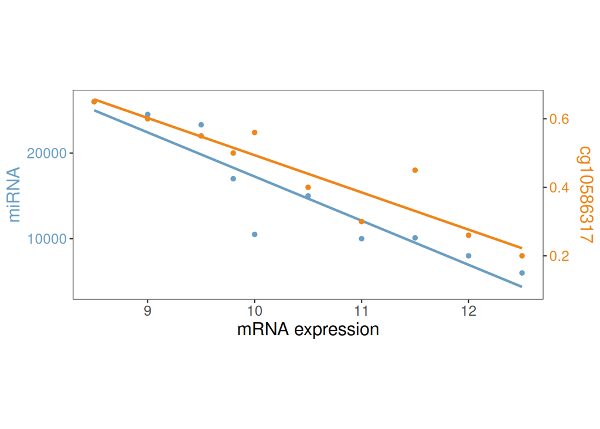

```r
p <- ggplot(inputData, aes(x=inputData$X )) +
  geom_point(aes(y=inputData$Y1), col=s1Colour) + #画X和Y1的散点 draw the scatter of X and Y1
  geom_smooth(aes(x=inputData$X, y=inputData$Y1),
              method="lm", se=F, col=s1Colour) + #添加线性拟合线 add linear fit line

  geom_point(aes(y=(inputData$Y2) * scaleFactor), col=s2Colour) + #画X和Y2的散点 draw the scatter of X and Y2
  geom_smooth(aes(x=inputData$X, y=inputData$Y2 * scaleFactor),
              method="lm", se=F, colour=s2Colour) + #添加线性拟合线 add linear fit line

  scale_y_continuous(name = ylefttitle,
                     #breaks = c(5000, 10000, 15000, 20000, 25000), #左侧Y轴刻度 left Y-axis scale
                     limits = c(0.1 * scaleFactor, NA), # 通过主轴下限控制右轴从0.1开始
                     sec.axis=sec_axis(trans = ~./scaleFactor, name = yrighttitle)) + #画右侧Y轴 draw the right Y-axis
  coord_fixed(ratio = ratioValues) + #坐标轴的宽高比 aspect ratio of coordinate axes

  labs(x=xtitle) + theme_bw() + #去除背景色 remove background color
  theme(panel.grid = element_blank(), #去除网格线 remove gridlines
        axis.title.x = element_text(size=15), #X轴题目字号 X-axis title font size
        axis.text.x = element_text(size=12), #X轴刻度字号 X-axis scale size
        axis.title.y.right = element_text(size=15, color = s2Colour, margin = margin(l = 6)), #右侧Y轴刻度字体的颜色 color of the right y-axis scale font
        axis.text.y.right = element_text(size=12, color = s2Colour), #右侧Y轴title颜色 right Y-axis title color
        axis.title.y.left = element_text(size=15, colour = s1Colour), #左侧Y轴刻度字体的颜色 color of the left Y-axis scale font
        axis.text.y.left = element_text(size=12, color = s1Colour)) #左侧Y轴title颜色 left Y-axis title color
p
```

把前面计算出的相关系数R1cor和R2cor标在图上

Label the previously calculated correlation coefficients R1cor and R2cor on the plot

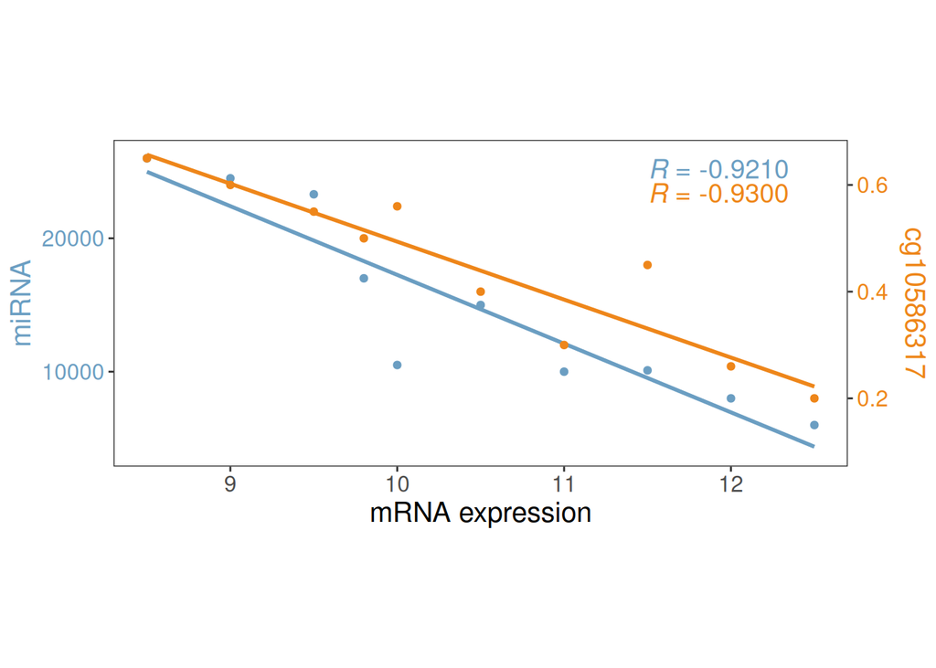

```r
# 相关系数在图上的位置，需根据你自己的数据灵活调整
# the position of the correlation coefficient on the graph needs to be adjusted flexibly according to your own data
x <- max(inputData$X)*(0.95)
y <- max(inputData$Y1)*(0.97)
y2 <- max(inputData$Y1)*(0.9)

# 标相关系数
# mark correlation coefficient
p1 <- p + annotate("text", x=x, y=y, label=R1cor, size=5, parse = TRUE, col=s1Colour ) +
  annotate("text", x=x, y=y2, label=R2cor, size=5, parse = TRUE, col=s2Colour )
p1
```

```r
# 保存到文件
# save to file
ggsave("TwoPlotOfLinearRegression.pdf", width = 6, height = 3)
```

右侧y轴的title头朝右，原文头朝左。我们用方法二来实现对原文完全复现。

The title head of the right y-axis faces right, and the original head faces left. We use method 2 to achieve an exact reproduction of the original text.

### 8.2 方法二 Method 2

先用ggplot2拿到两套坐标的plot object，修改之后重新画图。

First use ggplot2 to get the plot object for the two sets of coordinates, modify it and redraw it.

#### 8.2.1 用ggplot拿到两套坐标的plot object Use ggplot to get the plot object for two sets of coordinates

```r
#X和Y1的散点、拟合线、相关系数文字
#X and Y1 scatter, fitting lines, correlation coefficient text
p1 <- ggplot(inputData, aes(x=inputData$X, y=inputData$Y1)) +
  geom_point(col=s1Colour) +
  geom_smooth(aes(x=inputData$X, y=inputData$Y1), method="lm", se=F, col=s1Colour)+
  annotate("text", x=x, y=y , label=R1cor,size=5, parse = TRUE, col=s1Colour ) +
  annotate("text", x=x, y=y2, label=R2cor,size=5, parse = TRUE, col=s2Colour )+

  labs(x=xtitle, y=ylefttitle) + theme_bw()+
  theme(panel.grid = element_blank(), #去除网格线 remove gridlines
        axis.title.x = element_text(size=15),
        axis.text.x = element_text(size=12),
        axis.title.y = element_text(size=15, colour = s1Colour),
        axis.text.y = element_text(size=12, color = s1Colour))+
  coord_fixed(ratio = ratioValues)

#X和Y2的散点、拟合线、背景透明
#X and Y2 scatter, fitting lines, background transparency
p2 <- ggplot(inputData, aes(x=inputData$X, y=inputData$Y2)) +
  geom_point(col=s2Colour) +
  geom_smooth(aes(x=inputData$X, y=inputData$Y2), method="lm", se=F, colour=s2Colour)+

  labs(y=yrighttitle) + theme_bw() +
  scale_y_continuous(limits = c(0.1, NA)) +
  theme(panel.background = element_rect(fill = NA),
        panel.grid = element_blank(), #去除网格线 remove gridlines
        axis.title.y = element_text(size=15, color = s2Colour),
        axis.text.y = element_text(size=12, color = s2Colour)) +
  coord_fixed(ratio = ratioValues)

#提取plot object，保存到gtable数据结构里
#extract plot object, save to gtable data structure
g1 <- ggplot_gtable(ggplot_build(p1))
g2 <- ggplot_gtable(ggplot_build(p2))
#查看一下提取出的信息长啥样
#view what the extracted information looks like
head(g1$layout)
```

```
##     t l  b  r z clip       name
## 22  1 1 16 13 0   on background
## 1   8 6  8  6 5  off     spacer
## 2   9 6  9  6 7  off     axis-l
## 3  10 6 10  6 3  off     spacer
## 4   8 7  8  7 6  off     axis-t
## 5   9 7  9  7 1  off      panel
```

```r
head(g2$layout)
```

```
##     t l  b  r z clip       name
## 22  1 1 16 13 0   on background
## 1   8 6  8  6 5  off     spacer
## 2   9 6  9  6 7  off     axis-l
## 3  10 6 10  6 3  off     spacer
## 4   8 7  8  7 6  off     axis-t
## 5   9 7  9  7 1  off      panel
```

#### 8.2.2 重新画图 Redraw the picture

**提示：**选择从grid.newpage()到任意一个grid.draw(g)之间的部分一起运行，就会看到这部分代码的画图效果。

**Hint:** Select the part between grid.newpage() and any grid.draw(g) to run together to see the drawing effect of this part of the code.

```r
pdf("TwoPlotOfLinearRegression_plus.pdf", width = 6, height = 3) #想保存到pdf文件，就把这句前的#删掉，同时把最后一句dev.off()前面的#删掉 to save to a pdf file, remove the # before this sentence, and also remove the # before the last sentence dev.off()
grid.newpage()

#画X和Y1的散点、拟合线、相关系数文字
#draw X and Y1 scatter, fitting lines, correlation coefficient text
pp <- c(subset(g1$layout, name == "panel", se = t:r))
g <- gtable_add_grob(g1, g2$grobs[[which(g2$layout$name == "panel")]], pp$t,
                     pp$l, pp$b, pp$l)
#head(g)
grid.draw(g)

#画X和Y2的散点、拟合线
#draw X and Y2 scatter, fitting lines
ia <- which(g2$layout$name == "axis-l")
ga <- g2$grobs[[ia]]
ax <- ga$children[[2]]

ax$widths <- rev(ax$widths)
ax$grobs <- rev(ax$grobs)

# 把右移刻度数字移到边框外
# move the scale label to the outside of the border
shift_text_x <- function(g, dx){
  if (inherits(g, "text")) {
    if (!is.null(g$x)) g$x <- g$x + dx
    return(g)
  }
  if (!is.null(g$children)) {
    g$children <- lapply(g$children, shift_text_x, dx = dx)
  }
  if (!is.null(g$grobs)) {
    g$grobs <- lapply(g$grobs, shift_text_x, dx = dx)
  }
  return(g)
}
ax <- shift_text_x(ax, unit(7, "mm")) # 微调位置，根据实际情况调整 offset position, adjust according to the actual situation

g <- gtable_add_cols(g, g2$widths[g2$layout[ia, ]$l], length(g$widths) - 1)
grid.draw(g)

#画右侧Y轴刻度标签
#draw the right y-axis scale label
g <- gtable_add_grob(g, ax, pp$t, length(g$widths) - 1, pp$b)
grid.draw(g)

#画右侧Y轴title
#draw the right y-axis title
yLabTitle <- which(g2$layout$name == "ylab-l")
gaYLT <- g2$grobs[[yLabTitle]]
axYLT <- gaYLT$children[[1]]

axYLT$widths <- rev(axYLT$widths)
axYLT$grobs <- rev(axYLT$grobs)

g <- gtable_add_cols(g, g2$widths[g2$layout[yLabTitle, ]$l], length(g$widths) - 1)
g <- gtable_add_grob(g, axYLT, pp$t, length(g$widths) - 1, pp$b)

grid.draw(g)

dev.off()
```

[figure not shown]